# Rstudio Table Contest

Cedric Scherer

## Setup

```r
## R packages
library(tidyverse)
library(gt)
library(here)
library(glue)
library(ragg)

## Python libraries
#py_install("bs4")
#py_install("requests")
#py_install("time")
#py_install("re")
```

## Collect Data

### Scrappe Data from [IMDb’s Top 250 TV Shows](https://www.imdb.com/chart/toptv)

```r
## modified from https://github.com/WittmannF/imdb-tv-ratings/blob/master/IMDB_get_ratings.ipynb
if(!file.exists(here("data", "top250_allratings.Rds"))) {
  reticulate::source_python("src/get_imdb_data.py")

  df_top_series <-
    all_series %>%
    as_tibble() %>%
    mutate(rank = row_number())

  write_rds(df_top_series, here("data", "top250_ratings.Rds"))

  df_episodes <-
    ratings_df %>%
    all_ratings(rownames = pkgconfig::get_config("tibble::rownames", NULL)) %>%
    unnest(cols = c(Season, Episode))

  write_rds(df_episodes, here("data", "top250_allratings.Rds"))
} else {
  df_top_series <- read_rds(here("data", "top250_ratings.Rds"))
  df_episodes <- read_rds(here("data", "top250_allratings.Rds"))
}
```

### Source Data from [IMDb’s Interface Database](https://www.imdb.com/interfaces/)

```r
gz <- here("data", "title.basics.tsv.gz")
tsv <- here("data", "title.basics.tsv")

if (!file.exists(tsv)) {
  download.file("https://datasets.imdbws.com/title.basics.tsv.gz", gz)
}

gzfile(gz, 'rt')
```

```
## A connection with
## description "C:/Users/DataVizard/Google Drive/Work/DataViz/Personal/2020_RstudioTableContest/data/title.basics.tsv.gz"
## class       "gzfile"
## mode        "rt"
## text        "text"
## opened      "opened"
## can read    "yes"
## can write   "no"
```

```r
df_title_basics <-
  read_tsv(gz, col_types = list(runtimeMinutes = col_double())) %>%
  dplyr::select(tconst, originalTitle, runtimeMinutes, genres)

unlink(gz)
```

### Source [Ranking Data from 2019](https://github.com/WittmannF/imdb-tv-ratings) for Comparison

```r
path <- here("data", "top250list_May2019.csv")

if (!file.exists(path)) {
  download.file("https://raw.githubusercontent.com/WittmannF/imdb-tv-ratings/master/top250list.csv",
                here("data", "top250list_May2019.csv"))
}

df_data2019 <-
  read_csv(path) %>%
  dplyr::select(code = Code, rank2019 = Rank)
```

## Prepare Data

```r
df_top250 <-
  df_top_series %>%
  left_join(df_episodes, by = c("code" = "Code")) %>%
  mutate(
    ## clean some titles manually first
    rating = as.numeric(rating),
    Rating = as.numeric(Rating),
    year = as.numeric(str_sub(year, 2, 5)),
    title = str_replace_all(title, "MisteRogers", "Mister Rogers'"),
    title = if_else(year == 2010 & title == "Spartacus",
                    "Spartacus: Blood and Sand", title),
    title_id = glue::glue("{title} ({year})")
  ) %>%
  group_by(title_id) %>%
  arrange(Season, Episode) %>%
  mutate(id = row_number()) %>%
  dplyr::select(
    rank, title, title_id, code,
    year, id,
    season = Season,
    episode = Episode,
    rating = Rating,
    rating_avg = rating,
    rating_count,
    poster_url
  ) %>%
  arrange(rank, season, episode)

df_top250 <- df_top250 %>%
  filter(rank <= 100)
```

```r
df_best <-
  df_top250 %>%
  group_by(rank, title, code) %>%
  filter(rating == max(rating)) %>%
  mutate(best = glue("S{sprintf('%02d', season)}E{sprintf('%02d', episode)}")) %>%
  summarize(best = paste0(best, collapse = "<br>")) %>%
  mutate(best = glue("<span style='color:#02af74;'>{best}</span>"))
```

```r
table_data <-
  df_top250 %>%
  ## add additional information: oiginal title, runtime + genres
  left_join(df_title_basics, by = c("code" = "tconst")) %>%
  ## add string with top-rated episodes
  left_join(df_best) %>%
  mutate(best = if_else(is.na(best), glue("<i style='color:#ff8176;'>n.a.</i>"), best)) %>%
  ## add data from 2019 for comparison
  left_join(df_data2019) %>%
  mutate(diff = rank2019 - rank) %>%
  ## add missing genres and runtimes
  mutate(
    genres = case_when(
      ## ACTION
      title_id %in% c("Spartacus: Gods of the Arena (2011)") ~
        "Action,Adventure,Biography",
      title_id %in% c("Justified (2010)") ~
        "Action,Crime,Drama",
      title_id %in% c("Aranyélet (2015)") ~
        "Action,Drama,Thriller",
      ## ANIMATION
      title_id %in% c("Attack on Titan (2013)", "Vinland Saga (2019)", "Justice League Unlimited (2004)") ~
        "Animation,Action,Adventure",
      title_id %in% c("One Punch Man (2015)") ~
        "Animation,Action,Comedy",
      title_id %in% c("Demon Slayer: Kimetsu No Yaiba (2019)", "Archer (2009)") ~
        "Animation,Action,Comedy",
      title_id %in% c("Rick and Morty (2013)") ~
        "Animation,Adventure,Comedy",
      title_id %in% c("Over the Garden Wall (2014)") ~
        "Animation,Adventure,Drama",
      title_id %in% c("The Bugs Bunny Show (1960)", "The Bugs Bunny/Road Runner Hour (1968)") ~
        "Animation,Comedy",
      title_id %in% c("Death Note (2006)") ~
        "Animation,Crime,Drama",
      title_id %in% c("Erased (2016)") ~
        "Animation,Drama,Fantasy",
      ## BIOGRAPHY
      title_id %in% c("SCAM 1992: The Harshad Mehta Story (2020)", "Narcos (2015)") ~
        "Biography,Crime,Drama",
      title_id %in% c("Bose: Dead/Alive (2017)") ~
        "Biography,History,Mystery",
      ## COMEDY
      title_id %in% c("Monty Python's Flying Circus (1969)", "Fawlty Towers (1975)", "Detectorists (2014)", "Silicon Valley (2014)") ~
        "Comedy",
      title_id %in% c("Alfred Hitchcock Presents (1955)") ~
        "Comedy,Crime,Drama",
      title_id %in% c("TVF Pitchers (2015)", "Fleabag (2016)", "The Marvelous Mrs. Maisel (2017)", "Louie (2010)", "Horace and Pete (2016)") ~
        "Comedy,Drama",
      title_id %in% c("Inside No. 9 (2014)") ~
        "Comedy,Drama,Horror",
      title_id %in% c("This Is Us (2016)") ~
        "Comedy,Drama,Romance",
      title_id %in% c("The Grand Tour (2016)") ~
        "Comedy,TV-Show",
      ## CRIME
      title_id %in% c("Twin Peaks (2017)") ~
        "Crime,Drama,Fantasy",
      title_id %in% c("Persona (2018)", "Endeavour (2012)", "Big Little Lies (2017)") ~
        "Crime,Drama,Mystery",
      title_id %in% c("Breaking Bad (2008)", "Senke nad Balkanom (2017)", "Gomorrah (2014)", "Mindhunter (2017)", "Mr. Robot (2015)", "Ezel (2009)") ~
        "Crime,Drama,Thriller",
      ## DOCUMENTARY
      title_id %in% c("Planet Earth II (2016)", "Blue Planet II (2017)", "Life (2009)", "Chef's Table (2015)") ~
        "Documentary",
      title_id %in% c("The Defiant Ones (2017)") ~
        "Documentary,Biography,Crime",
      title_id %in% c("The Last Dance (2020)") ~
        "Documentary,Biography,History",
      title_id %in% c("The Jinx: The Life and Deaths of Robert Durst (2015)") ~
        "Documentary,Crime",
      title_id %in% c("Content Cop (2015)") ~
        "Documentary,Comedy,Crime",
      title_id %in% c("The World at War (1973)") ~
        "Documentary,History,War",
      ## DRAMA
      title_id %in% c("Succession (2018)") ~
        "Drama",
      title_id %in% c("The Twilight Zone (1959)") ~
        "Drama,Fantasy,Horror",
      title_id %in% c("The Haunting of Hill House (2018)") ~
        "Drama,Horror,Mystery",
      title_id %in% c("Skam (2015)", "Normal People (2020)") ~
        "Drama,Romance",
      ## MISC
      title_id %in% c("Mister Rogers' Neighborhood (1968)") ~
        "Family,Fantasy,Music",
      title_id %in% c("Queer Eye (2018)") ~
        "Reality-TV",
      TRUE ~ genres
    ),
    runtimeMinutes = case_when(
      title_id %in% c("Ezel (2009)") ~ 90,
      title_id %in% c("Endeavour (2012)") ~ 89,
      title_id %in% c("Horace and Pete (2016)") ~ 67,
      title_id %in% c("Persona (2018)") ~ 65,
      title_id %in% c("Senke nad Balkanom (2017)", "The Grand Tour (2016)", "Aranyélet (2015)", "Mindhunter (2017)", "Succession (2018)", "Twin Peaks (2017)", "The Defiant Ones (2017)", "Big Little Lies (2017)") ~ 60,
      title_id %in% c("The Marvelous Mrs. Maisel (2017)", "The Haunting of Hill House (2018)") ~ 57,
      title_id %in% c("Gomorrah (2014)", "The Bugs Bunny/Road Runner Hour (1968)", "Spartacus: Gods of the Arena (2011)") ~ 55,
      title_id %in% c("Blue Planet II (2017)", "The World at War (1973)") ~ 52,
      title_id %in% c("The Twilight Zone (1959)") ~ 51,
      title_id %in% c("Planet Earth II (2016)", "Chef's Table (2015)") ~ 50,
      title_id %in% c("Breaking Bad (2008)", "The Last Dance (2020)", "Narcos (2015)", "Mr. Robot (2015)") ~ 49,
      title_id %in% c("Life (2009)", "The Jinx: The Life and Deaths of Robert Durst (2015)") ~ 47,
      title_id %in% c("This Is Us (2016)", "Queer Eye (2018)") ~ 45,
      title_id %in% c("Justified (2010)") ~ 44,
      title_id %in% c("TVF Pitchers (2015)") ~ 40,
      title_id %in% c("Monty Python's Flying Circus (1969)", "Fawlty Towers (1975)", "Mister Rogers' Neighborhood (1968)", "The Bugs Bunny Show (1960)", "Skam (2015)", "Detectorists (2014)", "Erased (2016)", "Inside No. 9 (2014)") ~ 30,
      title_id %in% c("Silicon Valley (2014)") ~ 28,
      title_id %in% c("Fleabag (2016)") ~ 27,
      title_id %in% c("Demon Slayer: Kimetsu No Yaiba (2019)", "Alfred Hitchcock Presents (1955)") ~ 25,
      title_id %in% c("Death Note (2006)", "Attack on Titan (2013)", "One Punch Man (2015)", "Vinland Saga (2019)") ~ 24,
      title_id %in% c("Rick and Morty (2013)", "Justice League Unlimited (2004)") ~ 23,
      title_id %in% c("Archer (2009)", "Louie (2010)") ~ 22,
      title_id %in% c("Content Cop (2015)", "Bose: Dead/Alive (2017)") ~ 20,
      title_id %in% c("Normal People (2020)") ~ 16,
      title_id %in% c("Over the Garden Wall (2014)") ~ 11,
      TRUE ~ runtimeMinutes
    )
  ) %>%
  group_by(code) %>%
  mutate(
    ## correct runtime if time is voerall runtime not runtime per episode
    runtime = if_else(runtimeMinutes > 120 & title != "Critical Role",
                      round(runtimeMinutes / n(), 0),
                      runtimeMinutes),
    ## clean primary and original title
    title = str_replace_all(title, "\\s+and\\s+", " & "),
    title = str_replace_all(title, "'", "’"),
    originalTitle = if_else(is.na(originalTitle), "x", originalTitle),
    originalTitle = str_replace_all(originalTitle, "\\s+and\\s+", " & "),
    originalTitle = str_replace_all(originalTitle, "'", "’"),
    ## only add original title in case primary title != original title
    originalTitle = if_else(
      originalTitle %in% c(title, "x", "Only Fools and Horses....", "The X Files", "North & South", "Love, Death & Robots"),
      glue::glue(""),
      glue::glue("({originalTitle})")
    ),
    title = glue::glue("<div style='line-height:.85;'><b style='font-size:14px;'>{title}</b><span style='color:grey;font-size:9px;'>&nbsp;&nbsp;({year})</span><br><span style='color:grey;font-size:9px;'>{originalTitle}</span></div>"),
    ## nicely formatted genre list
    genres = if_else(is.na(genres),
                     "<i>not available</i>",
                     str_replace_all(genres, "\\,", "<br>")),
    ## to add stars to ratings we (mis)use suffixing as a trick
    rating_avg = rating_avg * 1000,
    ## overview of total number of seasons and episodes
    season_count = max(season),
    counts = case_when(
      season_count == 1 ~ glue("1 season  <br>{max(id)} episodes"),
      season_count > 1 ~ glue("{season_count} seasons <br>{max(id)} episodes"),
      is.na(season_count) ~ glue("<i style='color:#ff8176;'>not available</i>")
    ),
    ## nicely formatted rank difference to 2019
    change = case_when(
      diff > 0 ~ glue("<span style='color:#02af74;'>&uarr;+{diff}</span>"),
      diff < 0 ~ glue("<span style='color:#ffa500;'>&darr;{diff}</span>"),
      diff == 0 ~ glue("<span style='color:#b3b3b3;'>&bull;</span>"),
      is.na(rank2019) ~ glue("<span style='color:#9602c8;'>NEW!</span>")
    )
  ) %>%
  group_by(title_id, rank) %>%
  slice(1) %>%
  ungroup() %>%
  arrange(rank) %>%
  dplyr::select(
    rank,
    change,
    poster_url,
    title,
    runtime,
    genres,
    rating_avg,
    votes = rating_count,
    counts,
    best
  )
```

## Plots

### Rating Stripes

```r
plot_trends <- function(data){
  n <- data %>% filter(id %% 50 == 0) %>% pull(id)
  n <- c(n, 0)

  rect <- tibble(x1 = c(-Inf, max(data$id)), x2 = c(1, Inf), y1 = -Inf, y2 = Inf)

  g <- data %>%
    ggplot(aes(x = id, y = .5, fill = rating_norm)) +
    geom_tile(color = "transparent") +
    geom_step(aes(x = id + .5, y = rating_season), color = "grey20", size = 10) +
    geom_step(aes(x = id + .5, y = rating_season), color = "white", size = 6) +
    geom_rect(data = rect, aes(xmin = x1, xmax = x2, ymin = y1, ymax = y2),
              inherit.aes = FALSE,
              color = "transparent", fill = "white") +
    scale_x_continuous(expand = c(.0, 0), breaks = c(n, 0), labels = c(as.character(n), ""),
                       limits = c(1, unique(data$max_x))) +
    scale_y_continuous(expand = c(0, 0), limits = c(0, 1.05)) +
    # scale_x_continuous(breaks = n, , labels = c(as.character(n), ""),
    #                    limits = c(1, unique(data$max_x))) +
    # scale_y_continuous(expand = c(0, 0), limits = c(0, 1.18)) +
    scale_fill_gradient2(
      low = "#ffa500", mid = "grey90", high = "#02af74",
      midpoint = unique(data$avg),
      na.value = "transparent"
    ) +
    theme_void() +
    theme(legend.position = "none",
          axis.text.x = element_text(color = "grey60", size = 40, margin = margin(t = 10)))

  # if (unique(data$maxID) > 1) {
  #   g <- g +
  #   geom_point(data = data %>% filter(rating_norm == 1), aes(x = id, y = 1.1),
  #              shape = 25, color = "#02af74", fill = "transparent", size = 15, stroke = 4) +
  #   geom_point(data = data %>% filter(rating_norm == 0), aes(x = id, y = 1.1),
  #              shape = 25, color = "#ffa500", fill = "transparent", size = 15, stroke = 4)
  # }

  if (unique(data$title) == "The Simpsons") {
    g <- g + annotate(
      "text", x = 5, y = .35, color = "grey40", size = 26,
      fontface = "bold", lineheight = .9, hjust = 0,
      label = "There are too many episodes of “The Simpsons” to show them all.\nBut they are only getting worse anyway...")
  }
  g
}

table_trends <-
  df_top250 %>%
  group_by(title_id) %>%
  mutate(id = row_number()) %>%
  group_by(title_id, season) %>%
  mutate(rating_season = mean(rating, na.rm = TRUE) / 10) %>%
  group_by(title_id) %>%
  mutate(
    maxID = max(id),
    avg = (mean(rating, na.rm = TRUE) - min(rating, na.rm = TRUE)) / (max(rating, na.rm = TRUE) - min(rating, na.rm = TRUE)),
    rating_norm_season = (rating_season - min(rating, na.rm = TRUE)) / (max(rating, na.rm = TRUE) - min(rating, na.rm = TRUE)),
    rating_norm = (rating - min(rating, na.rm = TRUE)) / (max(rating, na.rm = TRUE) - min(rating, na.rm = TRUE)),
    rating_norm = if_else(maxID == 1, .5, rating_norm)
  ) %>%
  ungroup() %>%
  mutate(max_x = max(maxID[which(maxID < 400)])) %>%
  nest(ratings = c(-title_id, -rank)) %>%
  mutate(plot = map(ratings, plot_trends)) %>%
  arrange(rank)
```

### Runtime as Circles

```r
plot_runtime <- function(data){
  data %>%
    ggplot(aes(x = 1, y = 1, color = runtime)) +
    geom_point(aes(size = runtime), shape = 21, stroke = 7) +
    geom_text(
      aes(label = runtime_lab),
      size = 25,
      family = "Overpass Mono",
      fontface = "bold"
    ) +
    coord_cartesian(clip = "off") +
    scale_y_continuous(limits = c(.9, 1.13)) +
    scale_color_gradient(
      low = "grey65", high = "grey40",
      limits = c(data$runtime_min, data$runtime_max),
      na.value = "#ff8176"
    ) +
    scale_size(
      range = c(60, 140),
      limits = c(data$runtime_min, data$runtime_max)
    ) +
    theme_void() +
    theme(legend.position = "none")
}

table_runtime <-
  table_data %>%
  dplyr::select(rank, title, runtime) %>%
  mutate(
    runtime_min = if_else(is.na(runtime), NA_real_, min(runtime, na.rm = TRUE)),
    runtime_max = if_else(is.na(runtime), NA_real_, max(runtime, na.rm = TRUE)),
    runtime_lab = if_else(is.na(runtime), "n.a.", as.character(runtime))
  ) %>%
  nest(ratings = c(-rank)) %>%
  mutate(plot = map(ratings, plot_runtime))
```

## Tablelize It!

```r
imdb_table <-
  table_data %>%
  mutate(trends = NA) %>%
  gt() %>%
  ## COLORS --------------------------------------------------------------------
  data_color(
    columns = vars(rating_avg),
    colors = scales::col_numeric(
      palette = rev(rcartocolor::carto_pal(n = 7, name = "ag_GrnYl")),
      domain = NULL
    )
  ) %>%
  ## PLOTS ---------------------------------------------------------------------
  text_transform(
      locations = cells_body(vars(trends)),
      fn = function(x){
             map(table_trends$plot, ggplot_image, height = px(50), aspect_ratio = 9)
      }
  ) %>%
  text_transform(
      locations = cells_body(vars(runtime)),
      fn = function(x){
             map(table_runtime$plot, ggplot_image, height = px(50), aspect_ratio = 1)
      }
  ) %>%
  ## IMAGES --------------------------------------------------------------------
  text_transform(
    locations = cells_body(vars(poster_url)),
    fn = function(x){
      web_image(url = x, height = px(50))
    }
  ) %>%
  ## STYLE ---------------------------------------------------------------------
  fmt_markdown(columns = c("change", "title", "genres", "counts", "best")) %>%
  fmt_number(columns = c("rating_avg"), decimals = 1, suffixing = c(" ⭐")) %>%
  opt_table_font(
    font = list(
      google_font("Roboto Condensed"),
      google_font("Bitter"),
      google_font("Overpass Mono"),
      google_font("Alegreya Sans SC"),
      default_fonts()
    )
  ) %>%
  ## Titles & Co.
  tab_header(
    title = md("**What do I binge next?** An detailed overview of the Top 250 TV shows as rated by IMDb users")
  ) %>%
  tab_source_note(
    source_note = md("**Table: Cédric Scherer &bull; Data: IMDb.com**<span style='font-size:7pt;color:grey;'> (Last updated on Oct 26<sup>th</sup> 2020)</span>")
  ) %>%
  tab_footnote(
    footnote = md(glue("The line shows the average IMDb rating per season as the series progresses. Each vertical stripe represents one episode colored by the difference to the series' average (normalized). The plots are scaled to a maximum of {unique(table_trends$ratings[[1]]$max_x)} episodes; out of the top 250 only “The Simpsons” crossed that mark.<br>Ranks are compared to a dataset of the IMDb Top 250 TV series from May 2019.")),
    locations = cells_column_labels(columns = vars(trends))
  ) %>%
  ## Column Names
  cols_label(
    rank = "",
    change = "",
    poster_url = "",
    title = html("<span style='line-height:.85;'>Title<span style='font-size:9pt;color:grey;font-weight:400;'>&nbsp;&nbsp;(Start Year)</span></span>"),
    runtime = "Runtime",
    genres = "Genres",
    rating_avg = "Rating",
    votes = "Votes",
    counts = "Overview",
    best = html("<span style='line-height:.85;'>Top–Rated</span>"),
    trends = html("<span style='line-height:.65;'>Rating Trends:<br><i style='color:grey;font-weight:400;'>Are episodes <b style='color:#ffa500;'>worse</b> or <b style='color:#02af74;'>better</b> than the series’ average? </i></span>")
  ) %>%
  ## Column widths
  cols_width(
    vars(rank) ~ px(20),
    vars(change) ~ px(40),
    vars(poster_url) ~ px(50),
    vars(title) ~ px(300),
    #vars(runtime) ~ px(75),
    vars(genres) ~ px(85),
    vars(rating_avg) ~ px(90),
    #vars(votes) ~ px(55),
    vars(best) ~ px(90),
    vars(trends) ~ px(450)
  ) %>%
  ## Header Font
  tab_style(
    style = list(cell_text(font = "Alegreya Sans SC", weight = "bold",
                           color = "grey20", align = "center", v_align = "middle")),
    locations = list(cells_column_labels(gt::everything()))
  ) %>%
  tab_style(
    style = list(cell_text(font = "Roboto Condensed", align = "left")),
    locations = list(cells_title(groups = c("title")))
  ) %>%
  tab_style(
    style = list(cell_text(align = "left")),
    locations = list(cells_column_labels(c("title", "genres", "trends")))
  ) %>%
  tab_style(
    style = list(cell_text(align = "right")),
    locations = list(cells_column_labels(c("votes", "counts")))
  ) %>%
  ## Rank column
  tab_style(
    style = list(cell_text(font = "Overpass Mono", size = "small", align = "right")),
    location = list(cells_body(columns = vars(rank)))
  ) %>%
  ## Change Column
  tab_style(
    style = list(cell_text(font = "Overpass Mono", size = "x-small", align = "center")),
    location = list(cells_body(columns = vars(change)))
  ) %>%
  ## Title Column
  tab_style(
    style = list(cell_text(font = "Bitter", align = "left")),
    location = list(cells_body(columns = vars(title)))
  ) %>%
  ## Runtime Column
  tab_style(
    style = list(cell_text(font = "Roboto Condensed", align = "center")),
    location = list(cells_body(columns = vars(runtime)))
  ) %>%
  ## Genres Column
  tab_style(
    style = list(cell_text(font = "Roboto Condensed", size = "x-small", color = "grey", align = "left")),
    location = list(cells_body(columns = vars(genres)))
  ) %>%
  ## Rating Column
  tab_style(
    style = list(cell_text(font = "Overpass Mono", size = "small", weight = "bold", align = "center")),
    location = list(cells_body(columns = vars(rating_avg)))
  ) %>%
  ## Votes Column
  tab_style(
    style = list(cell_text(font = "Roboto Condensed", size = "x-small", align = "right", color = "grey")),
    location = list(cells_body(columns = vars(votes)))
  ) %>%
  ## Overview Column
  tab_style(
    style = list(cell_text(font = "Roboto Condensed", size = "x-small", align = "right", color = "grey")),
    location = list(cells_body(columns = vars(counts)))
  ) %>%
  ## Top–Rated Column
  tab_style(
    style = list(cell_text(font = "Roboto Condensed", size = "x-small", align = "center")),
    location = list(cells_body(columns = vars(best)))
  ) %>%
  tab_options(
    heading.align = "left",
    heading.title.font.size = 20,
    source_notes.font.size = 13,
    footnotes.font.size = 11,
    table.border.top.color = "transparent",
    table.border.bottom.color = "black",
    table.border.bottom.width = px(3),
    column_labels.border.top.width = px(3),
    column_labels.border.top.color = "black",
    table_body.hlines.color = "#ededed"
  )

imdb_table
```

**What do I binge next?** An detailed overview of the Top 250 TV shows as rated by IMDb users

Title (Start Year)

Runtime

Genres

Rating

Votes

Overview

Top–Rated

Rating Trends:  
*Are episodes **worse** or **better** than the series’ average?* <sup>1</sup>

1

•

[figure not shown]

**Planet Earth II** (2016)

Documentary

9.5

92,562

1 season  
6 episodes

S01E01

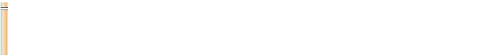

2

↑+2

[figure not shown]

**Planet Earth** (2006)

Documentary

9.4

163,744

1 season  
11 episodes

S01E01

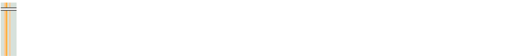

3

↓-1

[figure not shown]

**Band of Brothers** (2001)

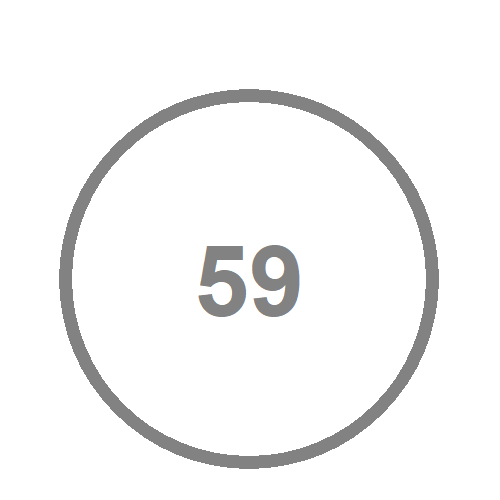

Action  
Drama  
History

9.4

364,616

1 season  
10 episodes

S01E09

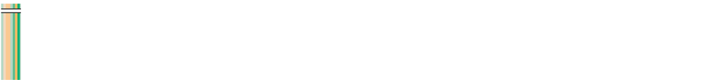

4

↑+1

[figure not shown]

**Breaking Bad** (2008)

Crime  
Drama  
Thriller

9.4

1,403,725

5 seasons  
62 episodes

S05E14

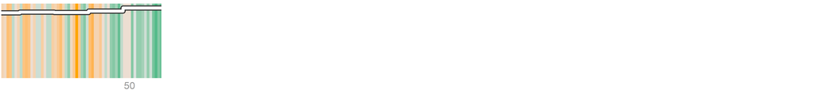

5

↑+7

[figure not shown]

**Chernobyl** (2019)

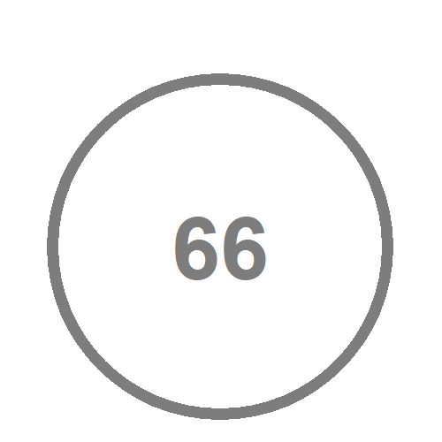

Drama  
History  
Thriller

9.4

502,294

1 season  
5 episodes

S01E05

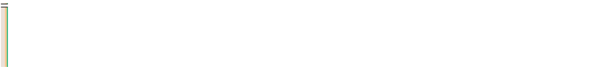

6

↑+1

[figure not shown]

**The Wire** (2002)

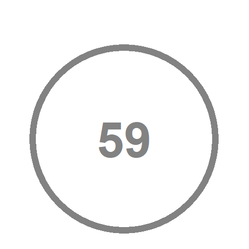

Crime  
Drama  
Thriller

9.3

276,781

5 seasons  
60 episodes

S03E11  
S05E10

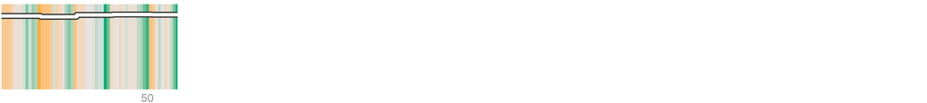

7

↑+1

[figure not shown]

**Blue Planet II** (2017)

Documentary

9.3

31,403

1 season  
8 episodes

S01E01

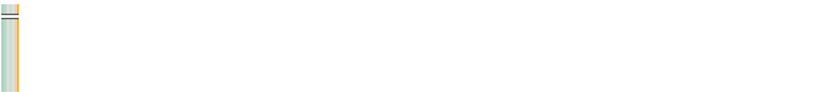

8

↓-2

[figure not shown]

**Our Planet** (2019)

Documentary

9.3

29,461

1 season  
8 episodes

S01E02

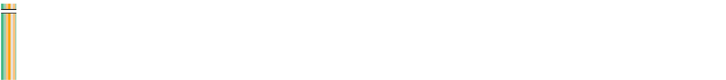

9

•

[figure not shown]

**Cosmos: A Spacetime Odyssey** (2014)

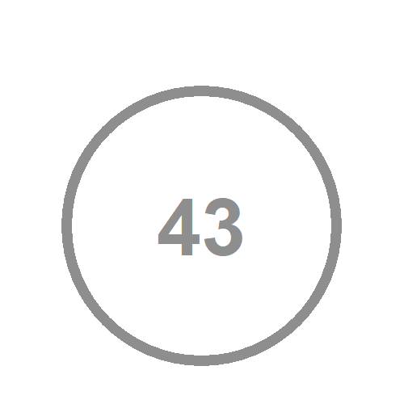

Documentary

9.2

108,371

1 season  
13 episodes

S01E13

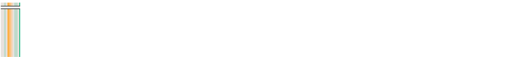

10

•

[figure not shown]

**Cosmos** (1980)

Documentary

9.2

35,723

1 season  
13 episodes

S01E08

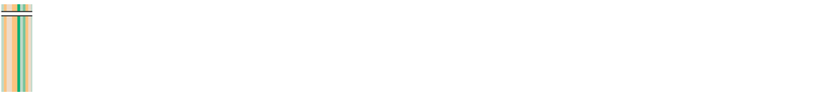

11

↓-8

[figure not shown]

**Game of Thrones** (2011)

Action  
Adventure  
Drama

9.2

1,715,645

8 seasons  
73 episodes

S03E09  
S05E08  
S06E09  
S06E10

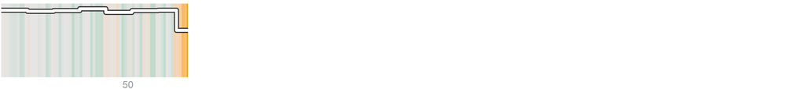

12

↑+3

[figure not shown]

**Avatar: The Last Airbender** (2005)

Action  
Adventure  
Animation

9.2

235,744

3 seasons  
62 episodes

S03E21

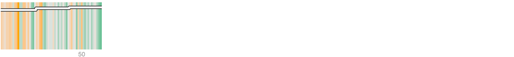

13

↓-2

[figure not shown]

**Rick & Morty** (2013)

Animation  
Adventure  
Comedy

9.2

358,197

4 seasons  
41 episodes

S03E07

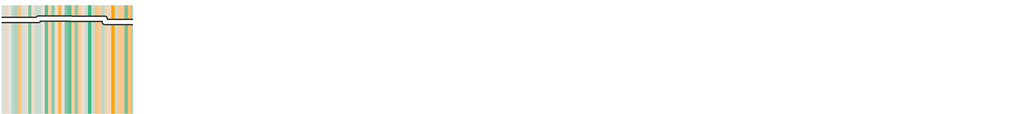

14

↓-1

[figure not shown]

**The Sopranos** (1999)

Crime  
Drama

9.2

289,990

6 seasons  
86 episodes

S03E11

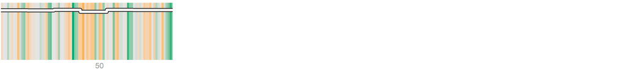

15

NEW!

[figure not shown]

**The Last Dance** (2020)

Documentary  
Biography  
History

9.1

69,124

1 season  
10 episodes

S01E10

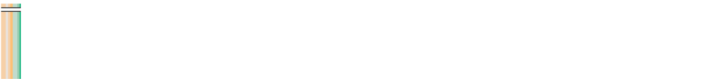

16

↓-2

[figure not shown]

**The World at War** (1973)

Documentary  
History  
War

9.1

21,514

1 season  
26 episodes

S01E09  
S01E20

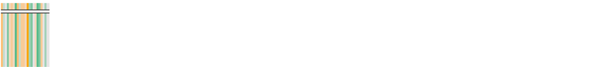

17

↓-1

[figure not shown]

**Life** (2009)

Documentary

9.1

37,372

1 season  
11 episodes

S01E01

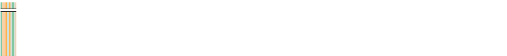

18

↑+6

[figure not shown]

**Fullmetal Alchemist: Brotherhood** (2009)  
(Hagane no renkinjutsushi)

Action  
Adventure  
Animation

9.1

111,275

1 season  
64 episodes

S01E19  
S01E63

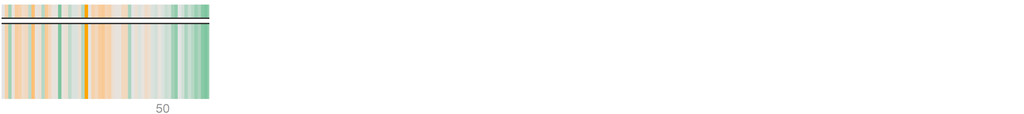

19

↓-1

[figure not shown]

**The Vietnam War** (2017)

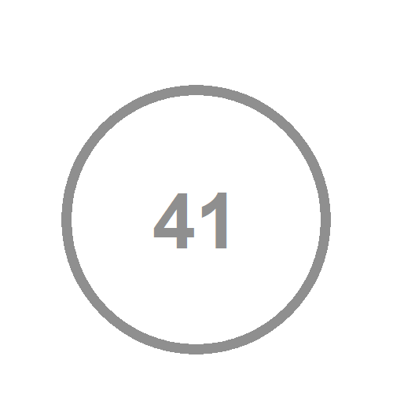

Documentary  
History  
War

9.1

19,273

1 season  
10 episodes

S01E06

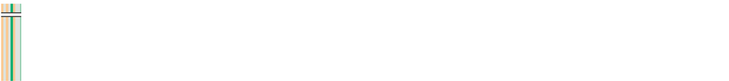

20

↓-3

[figure not shown]

**Sherlock** (2010)

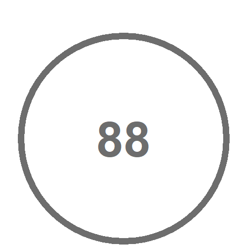

Crime  
Drama  
Mystery

9.0

784,067

4 seasons  
15 episodes

S02E03

[figure not shown]

21

↓-2

[figure not shown]

**The Twilight Zone** (1959)

Drama  
Fantasy  
Horror

9.0

69,254

5 seasons  
156 episodes

S02E06

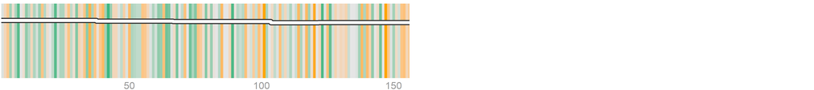

22

↓-2

[figure not shown]

**Human Planet** (2011)

Documentary

9.0

23,237

1 season  
8 episodes

S01E04

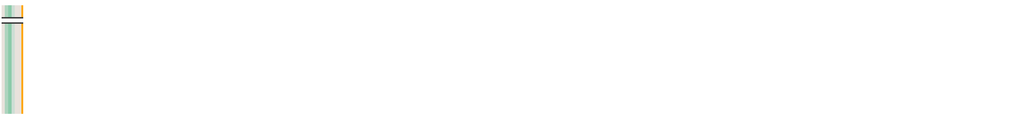

23

↑+36

[figure not shown]

**Persona** (2018)

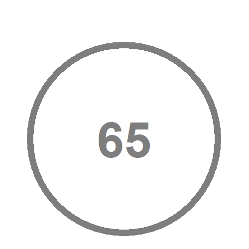

Crime  
Drama  
Mystery

9.0

27,410

1 season  
12 episodes

S01E12

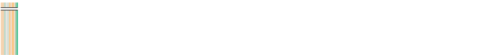

24

↑+6

[figure not shown]

**The Blue Planet** (2001)

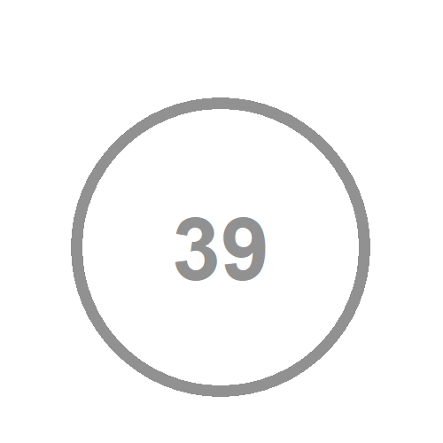

Documentary

9.0

33,793

1 season  
10 episodes

S01E02

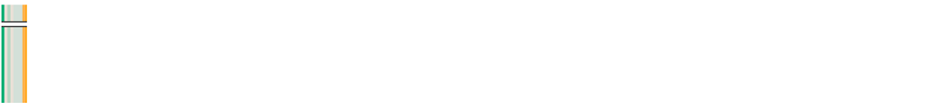

25